# Big Data Visualization

Selin Aytan , Idil Bukre Tuzkaya

2025-07-28

## **PREFACE**

### **Motivation and Goal**

This booklet was born out of a growing need to communicate complex data in a clear and accessible way. As data grows in volume and complexity, visual tools have become essential for uncovering insights that might otherwise remain hidden.

Motivated by a personal interest in data visualization, this project also aims to fill the gaps left by existing resources—many of which focus either too heavily on code or abstract theory. Our goal is to provide a guide that is technically sound yet simple and intuitive, aimed at readers with a basic understanding of data.

While various tools exist for visualization, this booklet focuses primarily on R, emphasizing its strengths in flexibility, reproducibility, and statistical integration. We also briefly compare R to other tools where relevant, to highlight why it was chosen and how it supports effective data storytelling from preparation to final presentation.

### **Challenges and Solutions During the Project**

Throughout the project, we encountered several challenges—both technical and conceptual. One of the first difficulties was handling large and complex datasets efficiently within the R environment. Some of the packages required for big data visualization demanded careful memory management and unfamiliar workflows, especially when working with tools like SparkR and Arrow.

Another major challenge was choosing the right type of visualization for different kinds of data and ensuring that the graphics remained both accurate and interpretable. It often took multiple iterations to find the right balance between simplicity and completeness.

We also spent considerable time understanding the underlying structure of the data and preparing it for analysis. Missing values, inconsistent formats, and merging different data sources required a lot of manual adjustment and trial-and-error.

Despite these challenges, we approached each problem methodically—consulting documentation, testing alternative solutions, and learning from examples and community discussions. These experiences not only strengthened our understanding of data visualization in R, but also improved our overall problem-solving skills in working with real-world data.

### **Target Audience**

This booklet is intended for students, early-stage researchers, and data enthusiasts who want to strengthen their understanding of data visualization using R. It assumes only a basic familiarity with data analysis and aims to present both core principles and practical examples in a clear and accessible way, making it useful for both beginners and those looking to refresh their skills.

### **Thanks**

This project was carried out as part of a summer internship at the University of Edinburgh, supported by the Erasmus+ programme. We would like to thank Ozan Evkaya, PhD for his valuable guidance and support throughout the process. His feedback and expertise greatly contributed to the development of this booklet.

# *TABLE OF CONTENT*

## **1.Introduction**

### *1.1 Purpose and Objectives of the Study*

In today’s world, with the explosive growth of data, deriving valuable insights and presenting them in a meaningful way has become ever more essential. Particularly, when working with big data, statistical analysis alone is often insufficient; supporting these analyses with powerful visualizations should be regarded as key priority in data-driven decision making.

This project aims to explore how classic visualization techniques are applied to “small” to “moderate” datasets to the realm of big data. Our project aims to demonstrate that data visualization is not merely about creating graphs, but about generating meaningful insights. It explores which types of graphs are suitable for different data structures, how to construct them using small to moderate datasets, and how these techniques applied when it comes to big data. Furthermore, the interactive dashboards and visualizations we used in this booklet targets foster engagement with reader. By doing so, we aim to contribute open-source materials and support R community. Main focuses of the project are:

- Improving practical skills while dealing with big data.
- Utilizing R tools such as Spark, Arrow, ggplot2, and tmap in order to create scalable and effective visual representations.
- Highlighting the differences between different types of data, and appyling proper visualizations for each.
- Safeguarding that visualizations are accessible and interpretable for both technical and general users.
- Promoting scientific transparency by designing reproducible analysis process.

Through this project, we intend to bridge the gap between big data and data visualization, illustrating how technical tools in data science can be used for powerful representations.

### *1.2 Overview of Datasets Used*

**Scottish Index of Multiple Deprivation 2020:** The Scottish Index of Multiple Deprivation is a relative measure of deprivation across 6,976 small areas (called data zones). If an area is identified as ‘deprived’, this can relate to people having a low income but it can also mean fewer resources or opportunities. SIMD looks at the extent to which an area is deprived across seven domains: income, employment, education, health, access to services, crime and housing. The dataset description was obtained from the Scottish Government’s [Official SIMD Documentation](https://www.gov.scot/collections/scottish-index-of-multiple-deprivation-2020/)

**Events Data:**

### *1.3 Project Roadmap*

This project follows a systematic approach: starting from data comprehension and preparation, moving on to creating effective visualizations, and finally scaling them to a big data context while ensuring reproducibility. Below is a an overview of the major stages:

**1. Data Exploration, Understanding, and Preprocessing**

In this step, EDA(Exploratory Data Analysis) was performed to gain a solid understanding of the datasets’ fundamental characteristics. This process involved handling missing values, assessing normality, and identifying data types. In order to apply various visualization techniques, we deliberately focused on datasets containing diverse data types. Main focus was primarily on Scotland based data, such as deprivation and Fringe datasets. In the end, the data was cleaned and prepared for visualization.

**2.Initial Visualizations with Small/Moderate Datasets**

For this step, we followed an iterative approach to decide which type of visualizations were suitable for each dataset in terms of aesthetics and readability. Testing these techniques initially on smaller datasets provided remarkable insights into how appropriate they scale in context of big data.

**3.Scaling Visualizations to Big Data**

**4.Spatial and Interactive Visualizations**

**5.Documentation and Reproducibility**

**6.Final Outputs and Contribution**

## **2.R Environment and Package Ecosystem**

### 2.2 Core Features of R We Utilized

### 2.3 Overview of Key Packages

- **Interactive Reporting:** `plotly` converted ggplot objects into zoomable, hover-enabled widgets. Full dashboards were assembled in Shiny, whose reactive model lets user inputs update outputs without additional JavaScript. When data lived on a Spark cluster, `sparklyr` exposed the same `dplyr` verbs, enabling Shiny panels to query distributed storage on demand.

Together, these packages provide a seamless toolchain: data flow from ingestion and cleaning through exploratory statistics, static and interactive graphics, spatial mapping, and finally to a web dashboard— all within a single, reproducible R environment.

### 2.4 Integration with Big Data Tools

To meet two opposing requirements—interactive analysis on a laptop and batch processing over terabyte-scale tables—this project employs a tiered architecture: Hadoop supplies reliable cluster storage and coarse-grain cleansing, Arrow delivers high-throughput columnar interchange to desktop R, and SparkR provides distributed, in-memory analytics when data volumes exceed local resources. Each layer therefore addresses a specific constraint (fault tolerance, I/O bandwidth, or compute parallelism) while exposing an R interface that preserves a single, reproducible code base.

- **SparkR for In-Memory Distributed Analytics** When full data volumes exceed workstation resources, the pipeline attaches to the institutional Apache Spark cluster through SparkR. Parquet files produced under Arrow are registered as Spark DataFrames; the familiar dplyr verbs are translated into Spark SQL and executed in parallel across worker nodes. Model artefacts needed for visualisation return to the driver as compact R objects, whereas voluminous prediction tables remain distributed on the cluster for downstream consumption.

By uniting Hadoop’s fault-tolerant storage, Arrow’s high-throughput columnar access, and SparkR’s distributed in-memory processing, the same R codebase scales effortlessly from laptop-sized prototypes to terabyte-level production workloads, offering rapid iteration in development and robust performance in deployment.

### 2.5 R Environment Setup

### Wrap-up

## **3. Fundamental Concepts of Data Visualization**

### 3.1 What is Data Visulization,Why Do We Need to Visualize?

### 3.2 Principles of Effective Visualization

### 3.3 Data Types and Appropriate Visualization Techniques

### Wrap-up

## **4. Pipeline & Data Preparation**

### *4.1 Importance of Data Preparation*

Data preparation is one of the most crucial steps for visualization. Raw data is often not suitable for further analysis. It may contain missing values, inappropriate data formats or variables that do not follow a normal distribution. Visualizing non-prepared data can yield us to misleading visualizations and wrong outcomes. Therefore, preparing data at first is an essential step, since proper preparation not only improves the quality but also increases transparency of visualizations. In this chapter, we will discuss how to prepare data in R environment for different sizes of datasets.

### *4.2 Preparation Process in R*

**For Multiple Deprivation Dataset:**

### *4.3 Normality Assesment*

**For Multiple Deprivation Dataset:**

This dataset contains 6976 observations. This number is quite big so tests like Shapiro Wilk Normality or Lilliefors Test may give inconsistent results, since these tests become sensitive to any small change as sample size increases. So the most valid option to asses normality here is drawing QQ-Plots of the variables we plan to use.

```r
library(readxl)
```

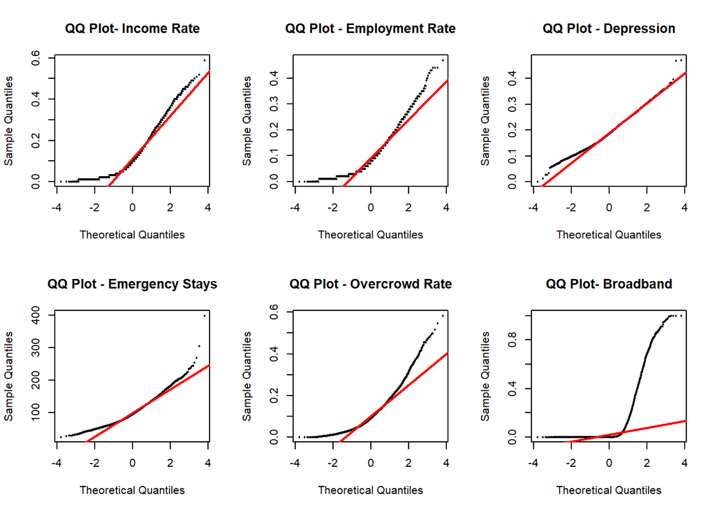

```r
data_path <- "data//simd2020_withgeog//simd2020_withinds.xlsx"
simd_data <- read_excel(data_path, sheet = "Data")

par(mfrow = c(2, 3))

qqnorm(simd_data$income_rate, col = "black", pch = 20, cex = 0.5, main = "QQ Plot- Income Rate");
qqline(simd_data$income_rate, col = "red", lwd = 2)

qqnorm(simd_data$employment_rate, col = "black", pch= 20, cex = 0.5, main = "QQ Plot - Employment Rate");
qqline(simd_data$employment_rate, col = "red", lwd = 2)

qqnorm(simd_data$DEPRESS, col = "black", pch = 20, cex = 0.5, main = "QQ Plot - Depression");
qqline(simd_data$DEPRESS, col = "red", lwd = 2)

qqnorm(simd_data$EMERG, col = "black", pch = 20, cex = 0.5, main = "QQ Plot - Emergency Stays");
qqline(simd_data$EMERG, col = "red", lwd = 2)

qqnorm(simd_data$overcrowded_rate, col = "black", pch=20, cex = 0.5, main = "QQ Plot - Overcrowd Rate");
qqline(simd_data$overcrowded_rate, col = "red", lwd = 2)

qqnorm(simd_data$broadband, col = "black", pch = 20, cex = 0.5, main = "QQ Plot- Broadband");
qqline(simd_data$broadband, col = "red", lwd = 2)
```

### 4.4 Challenges and Decisions

### Wrap-up

## **5. Exploratory Data Analysis (EDA)**

### 5.1 Summary Statistics

## **6. Visualizations**

### **6.1 Static Visualizations**

### **6.1.1 Bar Charts**

```r
library(dplyr)
```

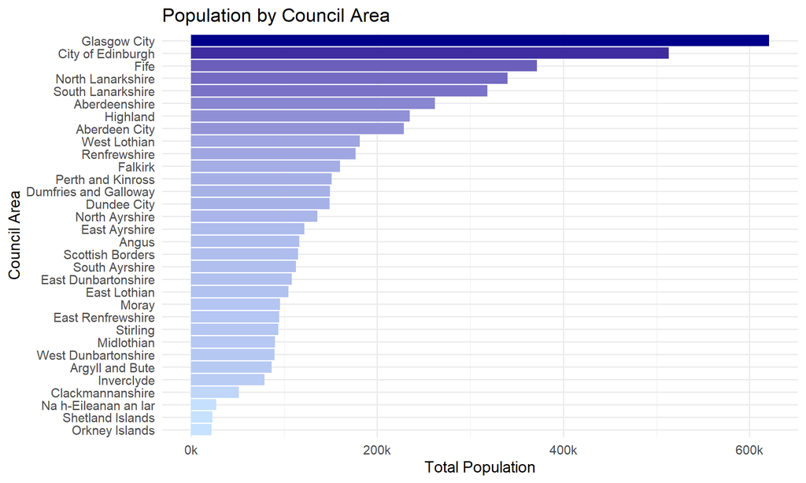

```r
library(ggplot2)
library(scales)

city_summary <- simd_data %>%
     group_by(Council_area) %>%
     summarise(Total_population = sum(Total_population, na.rm = TRUE)) %>%
     ungroup()

ggplot(city_summary, aes(x = reorder(Council_area, Total_population),
                         y = Total_population,
                         fill = Total_population)) +
  geom_col() +
  coord_flip() +
  scale_fill_gradient(high = "darkblue", low = "slategray1") +
  scale_y_continuous(labels = label_number(scale = 1e-3, suffix = "k")) +
  labs(title = "Population by Council Area",
       x = "Council Area", y = "Total Population") +
  theme_minimal(base_size = 14) +
  theme(legend.position = "none")
```

This horizontal bar chart shows the total population for each council area in Scotland, sorted from highest to lowest. Scottish Index of Multiple Deprivation 2020 dataset was used to create this visualization. First, data was grouped by council area and total population for each were calculated. `dplyr()` was used in this process while `ggplot2()` was used for creating the visualization. Features such as `geom_col()` and flipped coordinates made the graph easier to read. In order to enhance readability, `scales()` package was used to format the x-axis labels in thousands (k).

The chart has a gradient color scale, from `darkblue` for areas with higher population to `slategray1` for lower population areas.

It can be seen that Glasgow City has the highest population with more than 600k people followed by the capital city City of Edinburgh with around 500k people and Fife with about 350k while areas such as Shetland Islands and Orkney Islands have significantly less populations.

### 6.1.2 Histograms

### 6.1.3 Boxplots

### 6.1.4 Scatterplots

### **6.2 Multivariate Visualizations**

### 6.2.1 Faceting

```r
library(dplyr)
library(tidyr)
library(ggplot2)


metrics <- c("PT_retail", "PT_GP", "drive_primary", "drive_petrol")


city_summary <- simd_data %>%
  group_by(Council_area) %>%
  summarise(
    Total_population = sum(Total_population, na.rm = TRUE),
    across(all_of(metrics), ~ mean(.x, na.rm = TRUE))
  ) %>% ungroup()

top3  <- city_summary %>% arrange(desc(Total_population)) %>% slice_head(n = 3) %>%
  mutate(Group = "Highest 3 Populations")
bottom3 <- city_summary %>% arrange(Total_population) %>% slice_head(n = 3) %>%
  mutate(Group = "Lowest 3 Populations")

plot_data <- bind_rows(top3, bottom3) %>%
  pivot_longer(cols = all_of(metrics), names_to = "Metric", values_to = "Value")

metric_labels <- c(
  PT_retail     = "Public Transport Time to Retail",
  PT_GP         = "Public Transport Time to Healthcare Services",
  drive_primary = "Average Driving Time to Primary School",
  drive_petrol  = "Average Driving Time to Petrol Station"
)
```

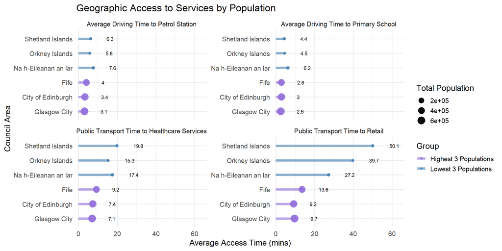

```r
ggplot(plot_data,
       aes(x = reorder(Council_area, Value), y = Value, color = Group)) +
  geom_segment(aes(xend = Council_area, y = 0, yend = Value), linewidth = 2, alpha = 0.6) +
  geom_point(aes(size = Total_population), alpha = 0.95) +
  geom_text(aes(label = round(Value, 1)),
            hjust = -0.2, nudge_y = 0.15*max(plot_data$Value, na.rm = TRUE),
            size = 3, color = "black") +
  coord_flip() +
  facet_wrap(~ Metric, ncol = 2, scales = "free_y",
             labeller = labeller(Metric = metric_labels)) +
  scale_size_continuous(range = c(2, 6)) +
  scale_color_manual(values = c("Highest 3 Populations" = "mediumpurple",
                                "Lowest 3 Populations"  = "steelblue")) +
  scale_y_continuous(expand = expansion(mult = c(0.02, 0.15))) +
  labs(
    title = "Geographic Access to Services by Population",
    x = "Council Area",
    y = "Average Access Time (mins)",
    size = "Total Population"
  ) +
  theme_minimal(base_size = 14)
```

The faceted lollipop charts above compares average access times to essential services for three most and least populated council areas in Scotland. Data was summarized using `dplyr()`, where the mean access time for each metric per council area was computed corresponding to the total population. Three most and least populated areas were filtered and reshaped with `tidyr()` and plotted with `ggplot2()`. Separate panels for each service type was created with `facet_wrap()` function with a consistent scale across all panels. Points represent the average access time in minutes with their size proportional to total population, and their colors indicating whether they belong to th highest or lowest population group.

The facet design reveals a clear pattern; low-population areas such as Orkney Islands, Na h-Eileanan an Iar, and Shetland Islands have significantly longer access times particularly for healthcare and retail via public transport, whereas high-population areas such as Edinburgh, Glasgow and Fife have considerably shorter access times across the board.

### 6.2.2 Heatmaps

### 6.2.3 Pair plots

### 6.1.5 Time Series

### **6.3 Themes, Labels, Scales**

### **6.4 Statistical Analysis and Visualizations**

### 6.4.1 Distribution & Density Plots

### 6.4.2 Linear and Multiple Regression

### 6.4.3 Confidence Intervals and Comparisons

### 6.4.4 Box Plots for Statistical Comparisons

```r
library(gridExtra)
```

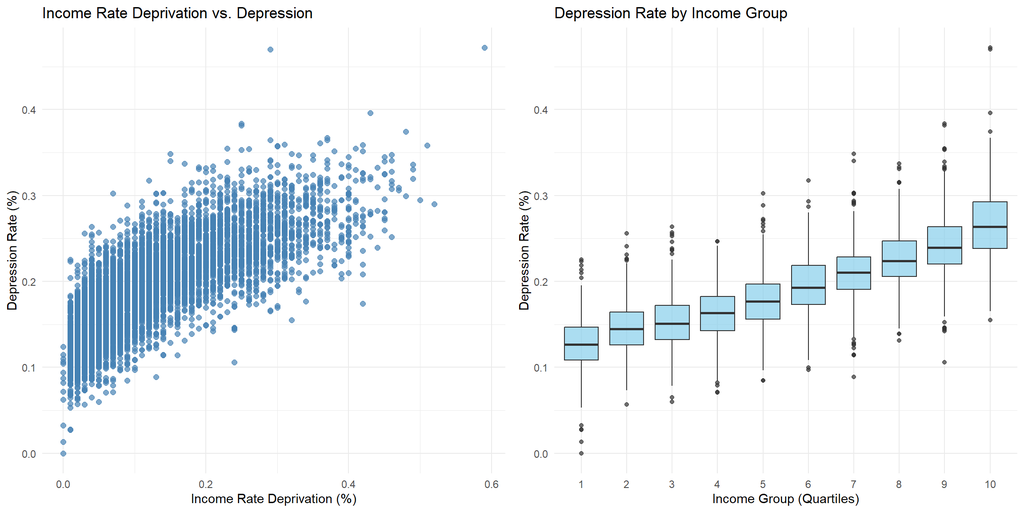

```r
library(dplyr)
library(ggplot2)
scatter <- ggplot(simd_data, aes(x = income_rate, y = DEPRESS)) +
  geom_point(color = "steelblue", size = 2, alpha = 0.7, na.rm = TRUE) +
  labs(
    title = "Income Rate Deprivation vs. Depression",
    x = "Income Rate Deprivation (%)",
    y = "Depression Rate (%)"
  ) +
  theme_minimal()

simd_data <- simd_data %>%
  mutate(income_group = ntile(income_rate, 10))

box <- ggplot(simd_data, aes(x = factor(income_group), y = DEPRESS)) +
  geom_boxplot(fill = "skyblue", alpha = 0.7, na.rm = TRUE) +
  labs(
    title = "Depression Rate by Income Group",
    x = "Income Group (Quartiles)",
    y = "Depression Rate (%)"
  ) +
  theme_minimal()

grid.arrange(scatter, box, ncol = 2)
```

The figure above shows the relationship between income rate deprivation and depression rate by combining two visualizations, using a scatter plot(left) and a box plot(right).

The scatter plot on the left side displays the relationship between income rate deprivation and depression rates. each point on the graph represents a single observation, revealing overall correlation and how data points are spread out across income deprivation levels. The plot shows a clear positive relationship , indicating that greater income deprivation is linked to higher depression rates. This type of plot is especially useful for identifying trends, patterns and possible outliers in raw data.

Conversely, the box plot on the right side groups the same observations into ten equal income groups based on deciles, which were calculated using the `ntile()` function. This grouping makes it possible and easier to compare distribution of depression rates within each income group. By summarizing the data into medians, quartiles and identifying outliers; the boxplot minimizes the effect of random noise and highlights systematic differences among the income groups. It is particularly useful for showing how central tendency and variability change as deprivation levels go up.

Ultimately, the dual approach lets us to see the big picture (scatter plot) and then verify whether the relationship is consistent by comparing summary statistics provided by grouped data(box plot).

### 6.4.5 ANOVA

### Wrap-up

## **7. Visualizing Geographical Patterns**

### 7.2 Merging Spatial and Non-Spatial Data

### 7.3 Mapping Tools and Packages in R

### 7.4 Thematic Mapping and Color Scales

### 7.5 Best Practices in Spatial Visualizations

```r
library(sf)
library(dplyr)
library(tmap)
library(geodata)

weight_by_population <- FALSE

pop_col <- "Total_population"


data_dir <- "data/gadm"
if (!dir.exists(data_dir)) dir.create(data_dir, recursive = TRUE)

uk_adm2 <- geodata::gadm(
  country = "GBR", level = 2, path = data_dir, version = "latest"
) |>
  st_as_sf()

scot_bndry <- uk_adm2 |>
  filter(NAME_1 == "Scotland") |>
  st_make_valid()


scot_bndry <- scot_bndry |>
  st_transform(27700) |>
  st_simplify(dTolerance = 100) |>
  st_transform(4326)

if (weight_by_population && pop_col %in% names(simd_data)) {
  area_summary <- simd_data |>
    filter(!is.na(.data[[pop_col]]), !is.na(employment_rate)) |>
    group_by(Council_area) |>
    summarise(
      employment_rate = sum(employment_rate * .data[[pop_col]]) / sum(.data[[pop_col]]),
      .groups = "drop"
    )
} else {
  area_summary <- simd_data |>
    group_by(Council_area) |>
    summarise(
      employment_rate = mean(employment_rate, na.rm = TRUE),
      .groups = "drop"
    )
}


map_df <- scot_bndry |>
  left_join(area_summary, by = c("NAME_2" = "Council_area")) |>
  mutate(emp_label = ifelse(is.na(employment_rate), NA, sprintf("%.1f%%", employment_rate)))


if (knitr::is_html_output()) {
  tmap_mode("view")
} else {
  tmap_mode("plot")
}
```

```r
tm_shape(map_df) +
  tm_polygons(
    col = "employment_rate",
    style = "quantile",
    n = 5,
    palette = "Blues",
    title = "Employment Rate\n(%)",
    id = "NAME_2",
    popup.vars = c(
      "Council area"     = "NAME_2",
      "Employment rate"  = "emp_label"
    )
  ) +
  tm_borders(alpha = 0.3) +
  tm_layout(
    main.title = "Employment Rate by Council Area in Scotland",
    main.title.size = 1.2,
    legend.outside = TRUE
  )
```

[output not shown]

[interactive chart not shown]

Above is an interactive choropleth map example of Scotland, representing employment rate by council area. For statistical values, Scottish Index of Multiple Deprivation 2020 dataset was used and administratiive boundaries are obtained from GADM(level 2) via `geodata::gadm()`

**Libraries used:** - `sf()` is used to read and transform polygons - `dplyr()` is used to aggregate and join the statistical data by council area - `tmap()` supports both static and interactive maps. Efficient to produce choroplets - `geodata()` is used to obtain current GADM boundaries automatically.

### Wrap-up

## **8. Interactive Visualizations**

### 8.1 Introduction to Interactivity in R

### 8.2 Building Interactive Plots with Plotly

### 8.3 Building Interactive Dashboards with Shiny

### Integrating Maps into Interactive Visualizations

### Considerations and Limitations

### Wrap-up

## **9. Findings and Insights**

### 9.1 Key Visual Patterns

### 9.2 Interpretation of Statistical Results

### 9.3 Challenges and Reflections

## **10. Conclusion**

### 10.1 Summary of Findings

### 10.2 Contributions and Future Work

## **REFERENCES**

## **APPENDIX**